# Lab 2

# Chapter 3: Describing, Exploring, and Comparing Data

## 3-1: Measures of Central Tendency

The measures of Center are the Mean, Median and Mode.

**Mean**

The mean is the arithmetic average of the data. It is the sum of all the individual data divided by the total number of data points.

The formula for the mean ($\bar{x}$) is:

$$\bar{x} = \frac{\sum x}{n}$$

Where: - $\sum x$: The sum of all data points. - $n$: The total number of data points.

In R, we can obtain the mean using the command

mean( )

**Example 1**

Listed below are the cotinine measurements (ng/ml) from a Smokers group. Find the mean of these 20 cotinine levels.

- 362 210 400 520 360 166 296 262 236 200
- 190 401 212 284 242 385 103 248 381 385

**Solution**

```r
cotinine <- c(362, 210, 400, 520, 360, 166, 296, 262, 236, 200, 190, 401, 212, 284,
                242, 385, 103, 248, 381, 385)
mean(cotinine)
```

```
## [1] 292.15
```

**Median** The median is the middle of the data when the data points are arranged in order of magnitude. It is also the 50th percentile. The median is preferred to the mean if we have skewed data because, unlike the mean, the median is not affected by outliers.

In R, we can obtain the median using the command

median( )

**Example 2**

Find the median of the first 11 cotinine values from the Smokers group. - 362 210 400 520 360 166 296 262 236 200 190

**Solution**

```r
cotinine <- c(362, 210, 400, 520, 360, 166, 296, 262, 236, 200, 190)

median(cotinine)
```

```
## [1] 262
```

**Mode** The mode is the value in the data with the highest frequency. R does not have a function to find the mode directly. To obtain the mode in R, we first create a frequency table using the R command table( ).

We then sort the elements in the table in decreasing order and select the first element using the function sort( table_name, decreasing = TRUE)[1] to obtain the mode if there is only one mode. If there is more than one mode, we use the following function: table_name[table_name == max(table_name) ) & table_name != 1]

**Example 4**

Find the mode of the 20 cotinine levels for Smokers, as listed here: - 362 210 400 520 360 166 296 262 236 200 - 190 401 212 284 242 385 103 248 381 385

**Solution**

```r
cotinine <- c(362, 210, 400, 520, 360, 166, 296, 262, 236, 200, 190, 401, 212,284,242, 385, 103, 248, 381, 385)

freq_cotinine <- table(cotinine)#This creates the freq table for the cotinine vector
freq_cotinine
```

```
## cotinine
## 103 166 190 200 210 212 236 242 248 262 284 296 360 362 381 385 400 401 520
##   1   1   1   1   1   1   1   1   1   1   1   1   1   1   1   2   1   1   1
```

```r
sort(freq_cotinine, decreasing = TRUE)[1]
```

```
## 385
##   2
```

Here, the mode is 385, and it has a frequency of 2.

## 3-2: Measures of Variation

The measures of variation are the measures of the spread of the data. They are the range, variance, standard deviation, and coefficient of variation. **Range** The range is the difference between the largest value and the smallest value The R command for finding the range is

range()

gives the largest and smallest values. To find the value of the range, we simply subtract the smallest value from the largest value. Alternatively, we can also use the R commands max(vector2) and min(vector1) to find the maximum and minimum values respectively, and subtract them. Or, we can simply type range(vector2) – range(vector1).

**Example 1**

Listed below are the first measured values of cotinine (ng/ml) from Smokers: - 362 210 400 520 360

Find the range.

**Solution**

```r
cotinine <- c(362, 210, 400, 520, 360)
range(cotinine)
```

```
## [1] 210 520
```

```r
range_value = 520 - 210
range_value
```

```
## [1] 310
```

**Variance** The sample variance is the average of the squared differences of the individual data points from the mean. The formula for the sample variance ($s^2$) is:

$$s^2 = \frac{\sum (x - \bar{x})^2}{n-1}$$

An alternative formula for finding the sample variance is:

$$s^2 = \frac{n\sum x^2 - (\sum x)^2}{n(n-1)}$$

The R command for finding the standard deviation is sd( )

**Example 2** Find the variance and standard deviation of these measured values of cotinine: - 362 210 400 520 360

**Solution**

```r
cotinine <- c(362, 210, 400, 520, 360)
var(cotinine)
```

```
## [1] 12290.8
```

```r
sd(cotinine)
```

```
## [1] 110.8639
```

**Coefficient of Variation** The coefficient of variation expresses the standard deviation relative to the mean. The formula for the coefficient of variation ($V$) is:

$$V = \frac{s}{\bar{x}} \times 100$$

Where: - $s$: The standard deviation. - $\bar{x}$: The mean.

The R code for finding the coefficient of variation is (sd( ) / mean( )) * 100 Note that this only works when the mean value is positive, which is usually the only case when a coefficient of variation is defined.

**Example 3** Use the data to determine range, variation, and standard deviation. **Solution**

```r
nicotine <- c(1.8, 1.7, 1.7, 1.6, 1.5, 1.4, 1.4, 1.3, 1.3, 1.2, 1.2, 1.1)
range(nicotine)
```

```
## [1] 1.1 1.8
```

```r
range_value <-1.8-1.1
range_value
```

```
## [1] 0.7
```

```r
var(nicotine)
```

```
## [1] 0.05151515
```

```r
sd(nicotine)
```

```
## [1] 0.2269695
```

## 3-3: Measures of Relative Standing and Boxplots

This section discusses the measures of relative standing, which are numbers that show the location of data values relative to other values within the same data set. We will discuss z-scores, Percentiles, Quartiles, five-number summaries, and Boxplots.

**z-Scores**

The z-score, also known as the standard or standardized score, is the number of standard deviations that a given value x is away from the mean. The formulas for the z-scores of the sample and population are:

### Sample Z-Score

$$z = \frac{x - \bar{x}}{s}$$

### Population Z-Score

$$z = \frac{x - \mu}{\sigma}$$

A z-score can be positive, negative, or zero. A negative z-score represents a score that is less than the mean, and a positive z-score represents a score that is greater than the mean. The z-score is zero when the score is equal to the mean. The R command for obtaining the z-scores of a vector of numbers is scale( ) To obtain the z-score for the nth term, type scale( )[n]

To clean things up and get a more legible output, you can use the command as.numeric( ) You can also compute the z-scores manually using the code (x -mean(x))/ sd(x)

**Example** Find the z-scores for the following data: - 112 141 118 132 121 116 133 110 126 138

**Solution**

```r
scores <- c(112, 141, 118, 132, 121,    116, 133, 110, 126, 138)
z_scores<- scale(scores)
z_scores1 <- as.numeric(z_scores) #This gives a cleaner output
z_scores1
```

```
##  [1] -1.1603672  1.4892902 -0.6121622  0.6669827 -0.3380597 -0.7948972
##  [7]  0.7583502 -1.3431022  0.1187777  1.2151877
```

**Percentiles** Percentiles are measures of location, denoted by $P_1, P_2, \dots, P_{99}$, that divide a set of data into 100 groups with about 1% of the values in each group.

The percentile that corresponds to a data value $x$ is given by the formula:

$$\text{Percentile of value } x = \frac{\text{number of values less than } x}{\text{total number of values}} \times 100$$

The R command is quantile(x, probs= c(p_1, p_2, .., p_n ) where x is the numeric vector whose percentile we wish to find, and probs is a numeric vector of probabilities. To find the percentile rank for a value x0 from a vector x, use the function (length(x[x <x0])/length(x))*100

To obtain percentile rank for all values in the vector, use the command (rank(x)-1)/length(x) Note that this command will not necessarily produce the same percentiles as the quantile function. The quantile function will fill in the gaps when we don’t have an exact multiple of 100.

**Example** The following data lists rounded cotinine measures (ng/ml) from 50 smokers randomly selected from Data Set 21 “Passive and Active Smoke”. These measures are arranged in increasing order. Find the percentile cotinine level of 250 ng/ml.

- 23 37 67 69 77 82 101 103 128 151
- 154 171 182 184 190 190 196 206 208 218
- 243 250 254 263 269 278 284 286 292 296
- 299 306 312 331 335 340 359 359 360 368
- 369 381 388 403 407 479 508 529 600 662

**Solution**

```r
Data1 <- c(23, 37, 67, 69, 77, 82, 101, 103, 128, 151, 154, 171, 182, 184, 190, 190,
             196, 206, 208, 218, 243, 250, 254, 263,269, 278, 284, 286, 292, 296, 299,
             306, 312, 331, 335, 340, 359, 359, 360, 368, 369, 381, 388, 403, 407,
             479, 508, 529, 600, 662)
(length(Data1[Data1<250])/length(Data1))*100
```

```
## [1] 42
```

Use the data in the Example to find the 25th percentile, $P25$. **Solution**

```r
quantile(Data1, probs = 0.25)
```

```
##   25%
## 182.5
```

**Quartiles** Quartiles are measures of location that divide a set of data into four groups with about 25% of the values in each group. The locations are denoted by $Q_1, Q_2,$ and $Q_3$.

Since the first, second, and third quartiles are the same as the 25th, 50th, and 75th percentiles respectively, we can use the R command for percentiles to find the quartiles. We can also use the command:

quantile(data, probs = c(0.25, 0.5, 0.75))

The difference between the first and third quartiles, $Q_3,- Q_1$ is known as the interquartile range. The R command for the interquartile range is IQR( )

**Five-number summary** The values the minimum, first quartile, second quartile (or median), third quartile, and maximum constitute the five-number summary. The R command for finding the five-number summary is fivenum( )

**Example** Use the cotinine measures in Data1 to find the 5-number summary.

**Solution**

```r
fivenum(Data1)
```

```
## [1]  23.0 182.0 273.5 359.0 662.0
```

**Boxplots** A boxplot or box-and-whisker plot is a graph of data that consists of a line extending from the point max(min(x), Q1 - (IQR(x)*1.5)) as the lower whisker to the point min(max(x), Q3 + (IQR(x)*1.5)) as the upper whisker, and a line drawn at the first quartile, the second quartile (median), and the third quartile.

This is a visual representation of a boxplot, showing the key components such as the lower whisker, Q1, median, Q3, and the upper whisker:

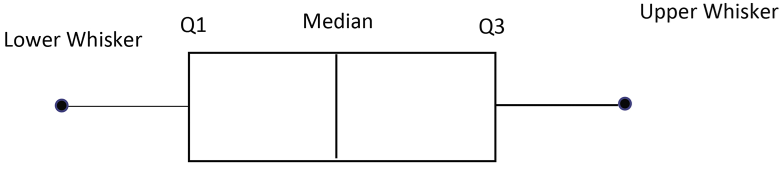

Boxplot Diagram

R command for the boxplot is

boxplot( )

**Example** Use the cotinine measurements listed in Data1 to construct a boxplot.

**Solution**

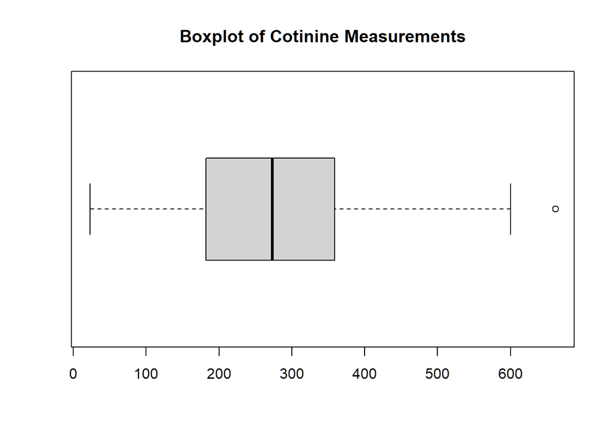

```r
boxplot(Data1, horizontal = TRUE, main ="Boxplot of Cotinine Measurements")
```